# Reunion 1 - Año 2023

## Paquetes que vamos a usar

```r
# tidyverse

library(tidyverse)

# para carga de datos

library(readxl)

library(here)

#
```

**1**

De acá usamos `ggplot2` para los gráficos; `dplyr` para manejos de datos; `forcats` para manejar los factores o variables categóricas

**2**

Con este paquete vamos a poder cargar archivos .xls o .xlsx

## Tipos de variables

- Cualitativas o categóricas

```r
tibble(pelo = c("unicolor",
                "bicolor",
                "tricolor"),
       juega = c("Si",
                 "No",
                 "No"),
       edad = c("cria",
                "joven",
                "adulto"))
```

**1**

En este caso la variable es dicotómica o binaria

**2**

En este caso la variable posee varias categorías

**3**

En R aparecen como chr o fct (factores). Estos últimos agrupan datos según su categoría

```
# A tibble: 3 × 3
  pelo     juega edad
  <chr>    <chr> <chr>
1 unicolor Si    cria
2 bicolor  No    joven
3 tricolor No    adulto
```

- Cuantitativas o numéricas

```r
tibble(gatos = c(2, 7, 1, 2, 2),
       temperatura_nariz = c(36.8, 35, 37.6, 38.2, 35))
```

```
# A tibble: 5 × 2
  gatos temperatura_nariz
  <dbl>             <dbl>
1     2              36.8
2     7              35
3     1              37.6
4     2              38.2
5     2              35
```

## Escalas de medición

- Nominal: clasificacion de objetos, personas, caracteristicas
- Ordinal: acá también tenemos categorías pero estas categorias siguen un orden especifico
- De intervalo: Estas son cuantitativas, pero en este caso el cero es arbitrario. (Temperatura, longitudes)
- De razón: en esta escala el cero es sinonimo de ausencia (Peso, altura)

```r
info_gatos <- tibble(pelo = c("unicolor",
                "bicolor",
                "tricolor",
                "bicolor",
                "bicolor"),
       juega = c("Si",
                 "No",
                 "No",
                 "Si",
                 "Si"),
       edad = c("adulto",
                "adulto",
                "cria",
                "joven",
                "cria"),
       temperatura_nariz = c(36.8, 35, 37.6, 38.2, 35),
       altura = c(.30, .42, .53, .25, .12))

info_gatos_2 <- info_gatos %>%
  mutate(pelo_factor = as_factor(pelo))

info_gatos_2 %>% count(pelo_factor)




#
```

**1**

En este caso se trata de una variable categorica nominal

**2**

Aca tenemos una variable categorica dicotomica

**3**

La variable edad seria (cuasi)cuantitativa ordinal

**4**

La temperatura de la nariz sera una variable cuantitativa de intervalo

**5**

Aca tenemos una variable cuantitativa de razón

```
# A tibble: 3 × 2
  pelo_factor     n
  <fct>       <int>
1 unicolor        1
2 bicolor         3
3 tricolor        1
```

## Cargando datos

```r
# devtools::install_github("toninif/iapsArgentina")

# Cargando usando readxl

estado_afectivo <- read_xlsx(here("datos/anexo_total.xlsx"),
                              na = "99999")

# Generando datos

set.seed(123)

datos_ejemplo <- tibble(valores = round(runif(20, min = 1, max = 10)))

datos_normales <- tibble(valor = rnorm(10000, mean = 0, sd = 1))

datos_normales2 <- tibble(valor = rnorm(10000, mean = 3, sd = 2))


#
```

**1**

Esto aparece así porque es un paquete que no está en CRAN. Entonces para instalarlo hace falta utilizar una función que pertenece al paquete `devtools`.

**2**

Este argumento esta bueno porque le indicamos a R que si hay un “99999” (o cualquier otra codificación) significa que tiene que leerlo como NA

**3**

Esto es por cuestiones de reproducibilidad. Si se cambia el seed o semilla, entonces se producen otros numeros. Si se lo deja igual, entonces no cambia.

**4**

Estos datos siguen una distribución normal

## Estadistica descriptiva

```r
resumen <- datos_ejemplo %>%
  summarise(
    media = mean(valores),
    mediana = median(valores),
    modo = as.numeric(names(table(valores))[table(valores) == max(table(valores))])
  )

resumen
```

```
# A tibble: 1 × 3
  media mediana  modo
  <dbl>   <dbl> <dbl>
1  5.95       6     9
```

## Media y mediana

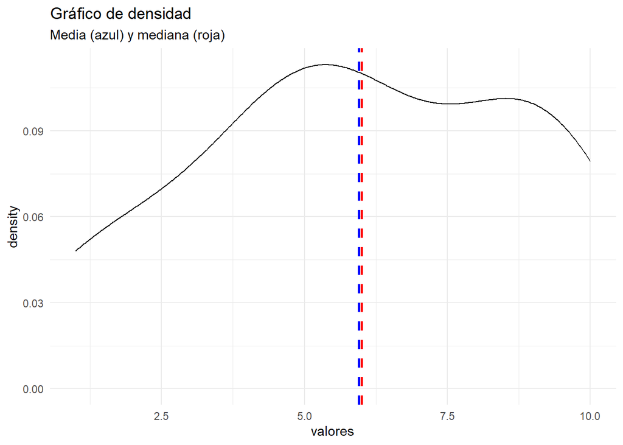

```r
# Gráfico de densidad
ggplot(datos_ejemplo, aes(x = valores)) +
  geom_density() +
  geom_vline(aes(xintercept = resumen$media), color = "blue", linetype = "dashed", linewidth = 1) +
  geom_vline(aes(xintercept = resumen$mediana), color = "red", linetype = "dashed", linewidth = 1) +
  labs(title = "Gráfico de densidad",
       subtitle = "Media (azul) y mediana (roja)") +
  theme_minimal()
```

## Modo

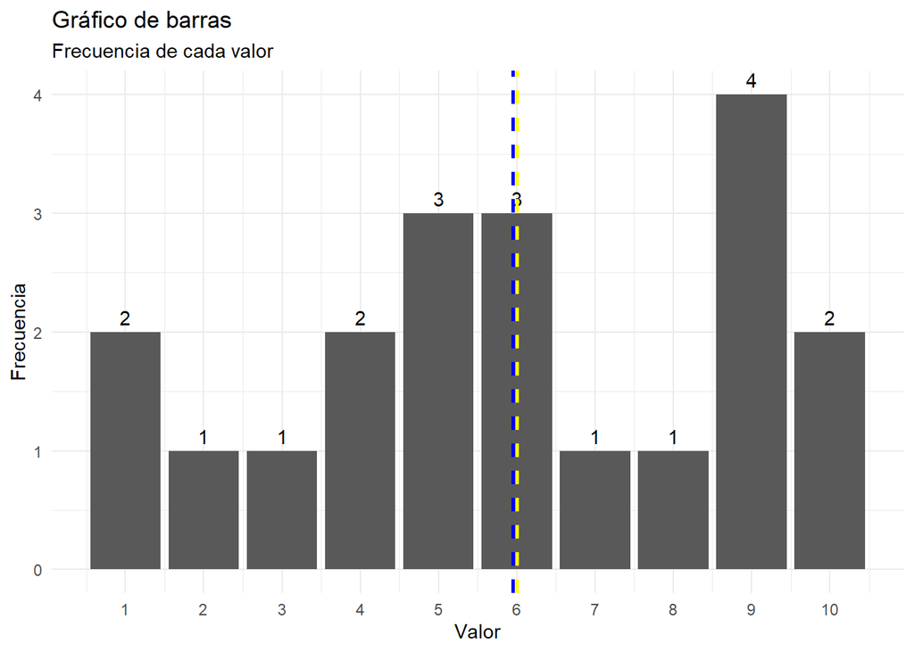

```r
# Gráfico de barras
datos_ejemplo %>%
  count(valores) %>%
  ggplot(aes(x = valores, y = n)) +
  geom_bar(stat = "identity") +
  geom_text(aes(label = n), vjust = -0.5) +
  scale_x_continuous(breaks = 1:10) +
  geom_vline(aes(xintercept = resumen$media), color = "blue", linetype = "dashed", linewidth = 1) +
  geom_vline(aes(xintercept = resumen$mediana), color = "yellow", linetype = "dashed", linewidth = 1) +
  labs(title = "Gráfico de barras",
       subtitle = "Frecuencia de cada valor",
       x = "Valor",
       y = "Frecuencia") +
  theme_minimal()
```

## Dispersion

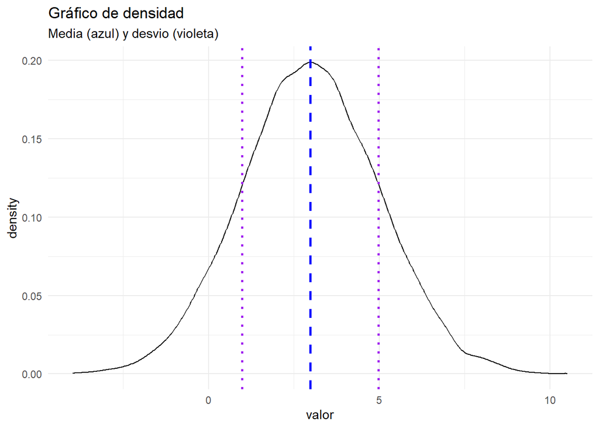

```r
ggplot(datos_normales2, aes(x = valor)) +
  geom_density() +
    geom_vline(aes(xintercept = mean(valor)), color = "blue", linetype = "dashed", size = 1) +
    geom_vline(aes(xintercept = mean(valor) - sd(valor)), color = "purple", linetype = "dotted", size = 1) +
    geom_vline(aes(xintercept = mean(valor) + sd(valor)), color = "purple", linetype = "dotted", size = 1) +
  labs(title = "Gráfico de densidad",
       subtitle = "Media (azul) y desvio (violeta)") +
  theme_minimal()
```

```r
#
```

## Ahora con una distribución normal

```r
resumen_normales <- datos_normales %>%
  summarise(
    media = mean(valor),
    mediana = median(valor)
  )

resumen_normales
```

```
# A tibble: 1 × 2
     media mediana
     <dbl>   <dbl>
1 -0.00213 -0.0111
```

### Graficos

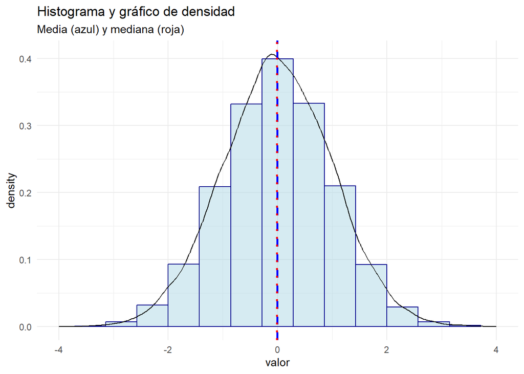

```r
ggplot(datos_normales, aes(x = valor)) +
  geom_histogram(aes(y = after_stat(density)), bins = 15, alpha = 0.5, colour = "darkblue", fill = "lightblue") +
  geom_density(color = "black") +
  geom_vline(aes(xintercept = resumen_normales$media), color = "blue", linetype = "dashed", linewidth = 1) +
  scale_x_continuous(limits = c(-4, 4)) +
  geom_vline(aes(xintercept = resumen_normales$mediana), color = "red", linetype = "dotted", linewidth = 1) +
  labs(title = "Histograma y gráfico de densidad",
       subtitle = "Media (azul) y mediana (roja)") +
  theme_minimal()
```

## Ahora con datos reales

```r
estado_afectivo %>%
  summarise(Valencia = mean(valenciaMedia),
            Activacion = mean(activacionMedia),
            Dominancia = mean(controlMedia))
```

```
# A tibble: 1 × 3
  Valencia Activacion Dominancia
     <dbl>      <dbl>      <dbl>
1     4.34       5.41       5.17
```

### Queremos ver como es la distribucion de alguna de mis variables. Por ejemplo la valencia

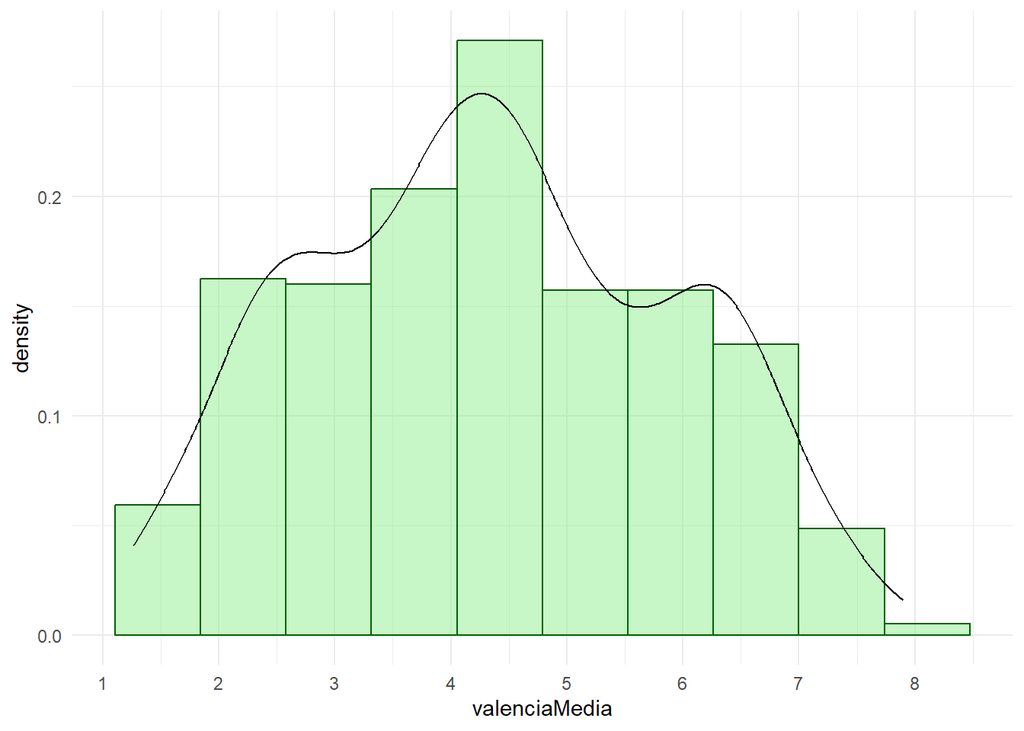

```r
ggplot(estado_afectivo, aes(x = valenciaMedia)) +
  geom_histogram(aes(y = after_stat(density)), bins = 10, alpha = 0.5, colour = "darkgreen", fill = "lightgreen") +
  geom_density(colour = "black") +
  scale_x_continuous(breaks = 1:9) +
  theme_minimal()
```

Lo mismo se puede hacer con la activación emocional

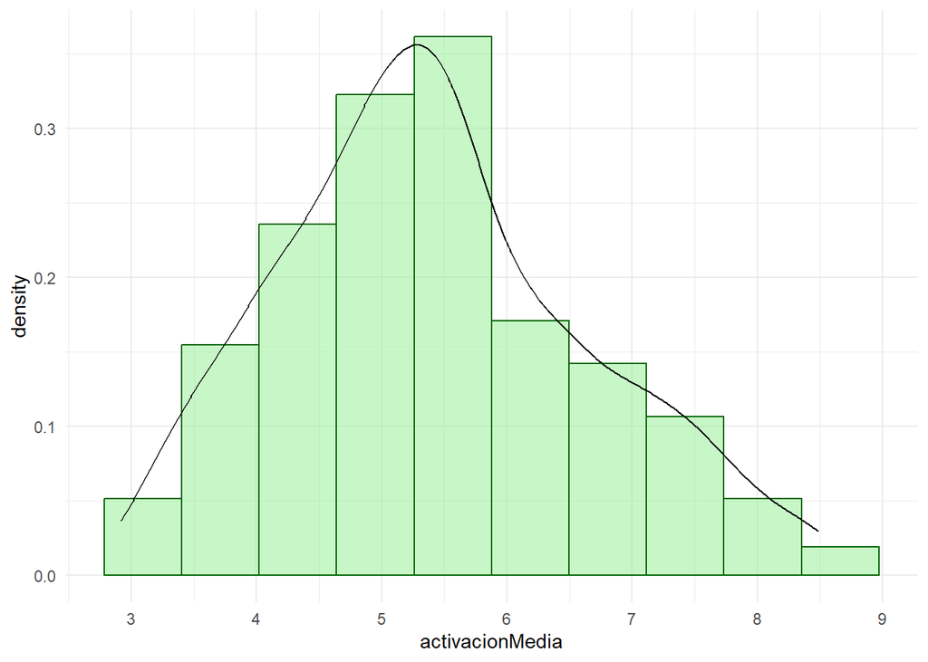

```r
ggplot(estado_afectivo, aes(x = activacionMedia)) +
  geom_histogram(aes(y = after_stat(density)), bins = 10, alpha = 0.5, colour = "darkgreen", fill = "lightgreen") +
  geom_density(colour = "black") +
  scale_x_continuous(breaks = 1:9) +
  theme_minimal()
```

```r
estado_afectivo %>%
  group_by(poblacion) %>%
  summarise(valencia = mean(valenciaMedia),
            activacion = mean(activacionMedia))
```

```
# A tibble: 3 × 3
  poblacion valencia activacion
  <chr>        <dbl>      <dbl>
1 General       4.33       5.41
2 Hombres       4.42       5.43
3 Mujeres       4.28       5.41
```

```r
diferencias_hym <- estado_afectivo %>%
  filter(poblacion %in% c("Hombres", "Mujeres")) %>%
  mutate(poblacion_factor = as_factor(poblacion))

t.test(diferencias_hym$valenciaMedia ~ diferencias_hym$poblacion_factor, alternative = "two.sided")
```

```
    Welch Two Sample t-test

data:  diferencias_hym$valenciaMedia by diferencias_hym$poblacion_factor
t = -0.84414, df = 331.33, p-value = 0.3992
alternative hypothesis: true difference in means between group Mujeres and group Hombres is not equal to 0
95 percent confidence interval:
 -0.4761019  0.1901867
sample estimates:
mean in group Mujeres mean in group Hombres
             4.278905              4.421863
```